# Practice Session & Exercise

Introduction to R and Basic Programming Concepts

Author

Affiliation

Bioinformatics Core Facility CECAD

Published

September 24, 2026

# 1 [Intermediate R-Course 2026](https://cecadbioinformaticscorefacility.github.io/Intermediate_R_Course_2026/)

# 2 Session 3 Practice: ggplot2

This one-hour practice session follows the slides and the Kahoot quiz. Try each task before you open the solution. The exercises use `iris`, the built-in plant-physiology dataset `CO2`, and `ggplot2`.

Not everyone works through exercises at the same pace, so each one below is flagged — but the exercises build on each other, so everyone still works through them **in order, together as a group**. The flags aren’t an invitation to skip ahead; they tell you what to expect, and what to do if you’re falling behind:

- 🟢 **Easy** — everyone should get through these by writing the code themselves.
- 🟡 **Medium** — a bit harder, or an optional add-on; keep typing if you’re keeping pace, but copying from the solution is fine too.
- 🔴 **Challenge** — the most demanding exercises, including today’s only new programming idea (writing your own function). If you’re falling behind, copy the code from the solution instead of typing it yourself, then move on together with the group.

## 2.1 Session 3

### 2.1.1 Exercise 1: Fixed versus mapped colour 🟢 Core

Start with this scatter plot:

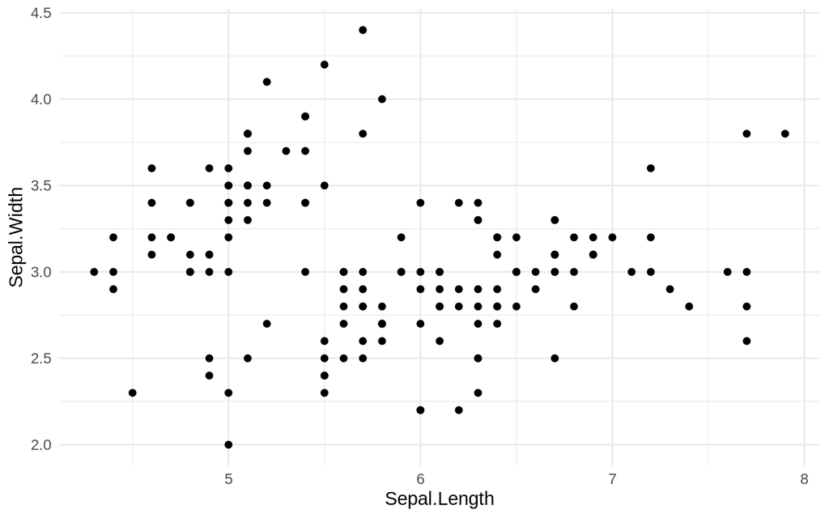

```r
p <- ggplot(iris, aes(Sepal.Length, Sepal.Width)) +
  geom_point()
print(p)
```

Create two named versions:

- `p_grouped`: map `Species` to `colour` so a legend appears.
- `p_fixed`: make every point one fixed blue colour.

Print both versions. Which one has a legend, and why?

*Solution 1*.

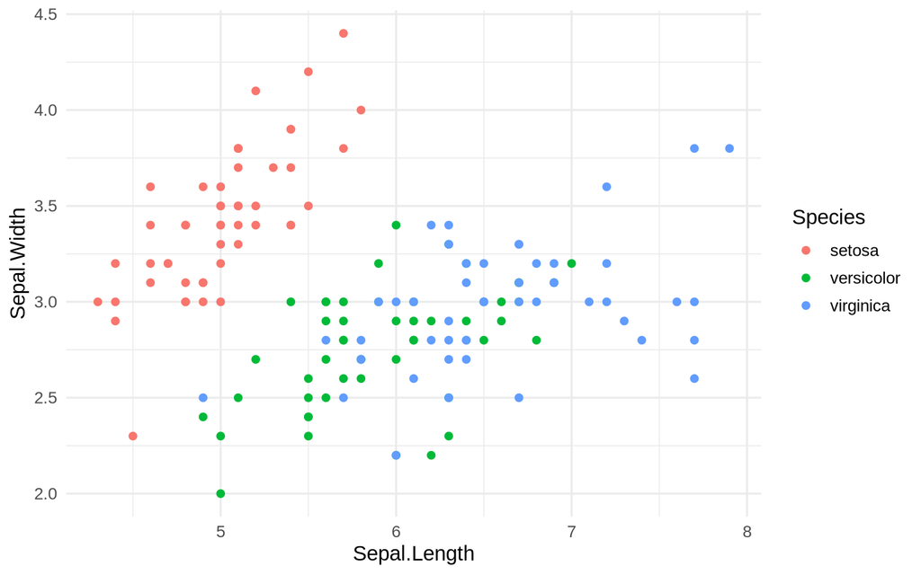

```r
p_grouped <- p + aes(colour = Species)

p_fixed <- ggplot(iris, aes(Sepal.Length, Sepal.Width)) +
  geom_point(colour = "#0072B2")

print(p_grouped)
```

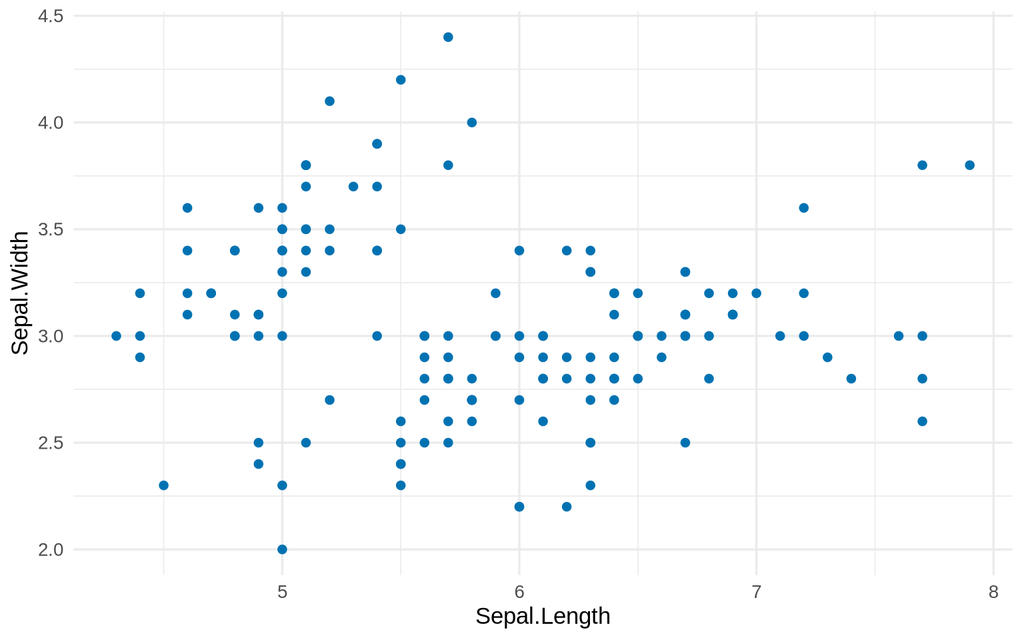

```r
print(p_fixed)
```

### 2.1.2 Exercise 2: Extend a plot object without overwriting it 🟢 Core

Using `p_grouped` from Exercise 1, create three named versions:

- `p_trend`: add one linear trend per species with `geom_smooth(method = "lm", se = FALSE)`.
- `p_panels`: split the plot into species panels with `facet_wrap(~ Species)`.
- `p_report`: start from `p_panels`, then add labels and `theme_classic()`.

Print `p_report` and then print `p_grouped`. Is the original still unchanged?

*Solution 2*.

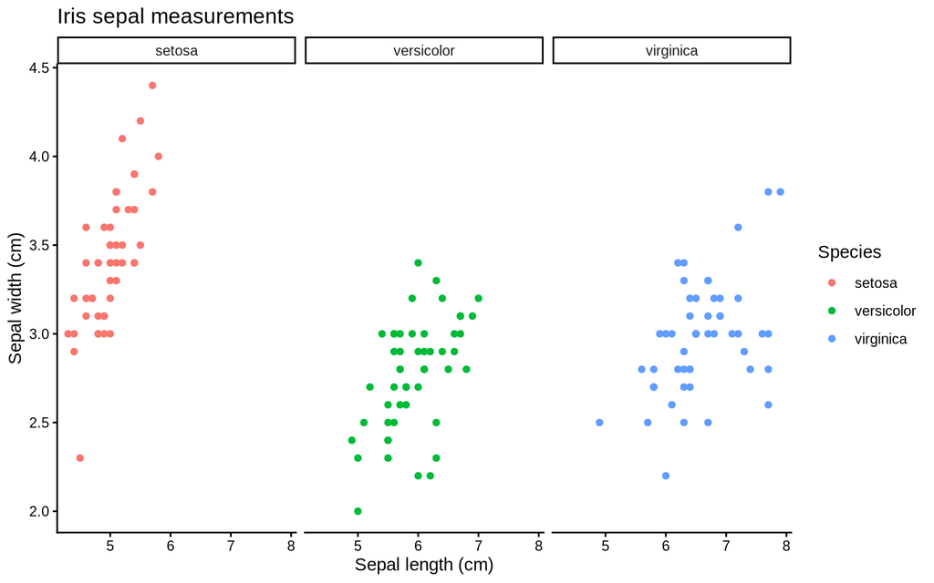

```r
p_trend <- p_grouped +
  geom_smooth(method = "lm", se = FALSE)

p_panels <- p_grouped +
  facet_wrap(~ Species)

p_report <- p_panels +
  labs(
    title = "Iris sepal measurements",
    x = "Sepal length (cm)",
    y = "Sepal width (cm)",
    colour = "Species"
  ) +
  theme_classic()

print(p_report)
```

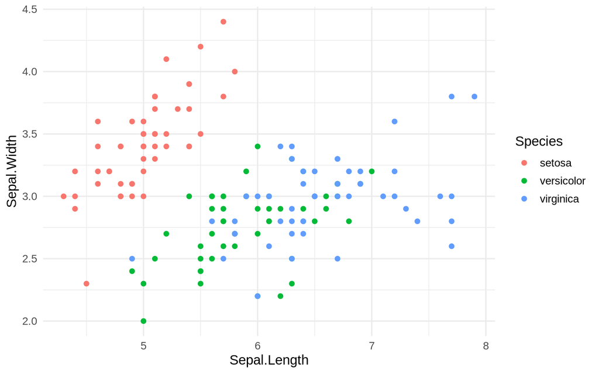

```r
print(p_grouped)
```

### 2.1.3 Exercise 3: Put plot objects in lists and functions 🔴 Challenge

Keep the versions from Exercise 2 in a list called `plots`, with elements named `grouped`, `trend`, `panels`, and `report`.

Then write `render_plot(plot, file)` using `ggsave()`. Use it to save the `report` version as `iris_report.png`.

*Solution 3*.

```r
plots <- list(
  grouped = p_grouped,
  trend = p_trend,
  panels = p_panels,
  report = p_report
)

render_plot <- function(plot, file) {
  ggsave(
    filename = file,
    plot = plot,
    width = 8,
    height = 5,
    units = "in",
    dpi = 300
  )
  invisible(file)
}

dir.create("ggplot2_practice_output", showWarnings = FALSE)
render_plot(
  plots$report,
  "ggplot2_practice_output/iris_report.png"
)
```

### 2.1.4 Exercise 4: Choose the geom and add observations 🟡 Stretch

Using `iris`, make three complementary plots:

1. A count of flowers in each species with `geom_bar()`.
2. A histogram of `Petal.Length`. Compare `binwidth = 0.5` and `binwidth = 1`.
3. A boxplot of `Petal.Length` by species with jittered observations.

Optional: create a count table with `dplyr::count()` and reproduce the first plot with `geom_col()`. What changes when the y values are supplied?

*Solution 4*.

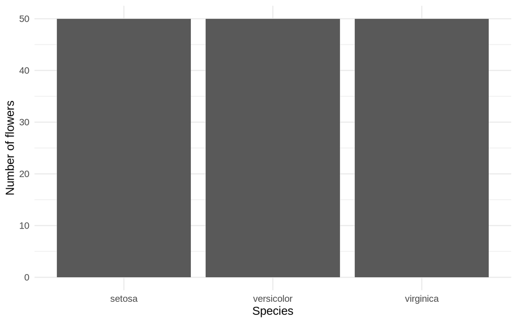

```r
p_bar <- ggplot(iris, aes(Species)) +
  geom_bar() +
  labs(x = "Species", y = "Number of flowers")

sp_counts <- count(iris, Species)
p_col <- ggplot(sp_counts, aes(Species, n)) +
  geom_col() +
  labs(x = "Species", y = "Number of flowers")

p_hist <- ggplot(iris, aes(Petal.Length)) +
  geom_histogram(binwidth = 0.5, boundary = 0, colour = "white") +
  labs(x = "Petal length (cm)", y = "Number of flowers")

p_box <- ggplot(iris, aes(Species, Petal.Length)) +
  geom_boxplot(outlier.shape = NA) +
  geom_jitter(width = 0.12, height = 0, alpha = 0.7) +
  labs(x = "Species", y = "Petal length (cm)")

print(p_bar)
```

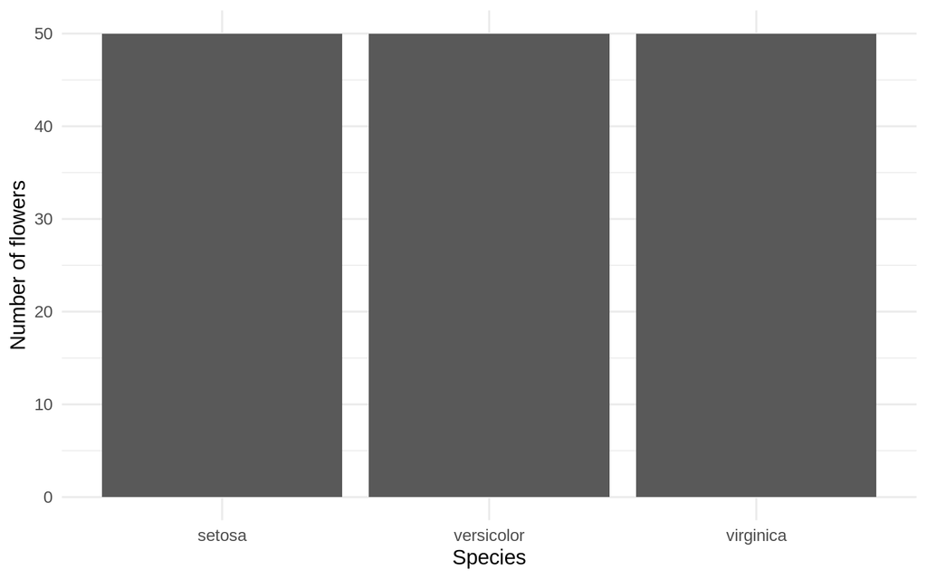

```r
print(p_col)
```

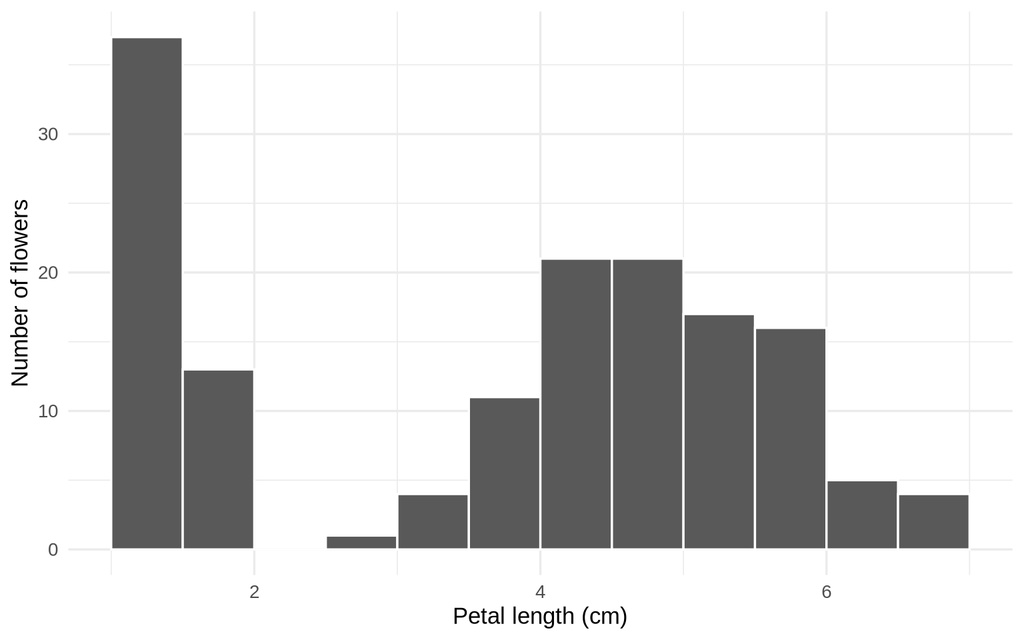

```r
print(p_hist)
```

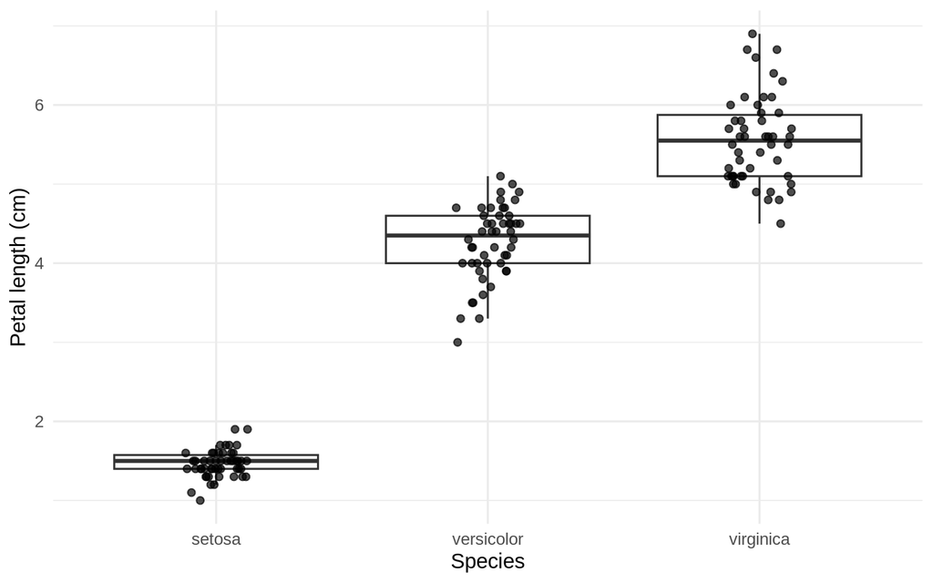

```r
print(p_box)
```

### 2.1.5 Exercise 5: Capstone figure and reproducible outputs 🔴 Challenge

`iris` only gives one grouping variable (`Species`), so for a figure that needs two we switch to another built-in biological dataset: `CO2`, CO2 uptake rates in chilled and non-chilled grass plants from Quebec and Mississippi (see `?CO2`).

Build one figure in named stages. The final plot should:

- put `conc` (ambient CO2 concentration) on x and `uptake` on y;
- colour points by `Type` (Quebec vs. Mississippi);
- add one linear trend per `Type`;
- split into panels by `Treatment` (chilled vs. nonchilled);
- include readable labels, a title, and a clean theme.

Keep `p_points`, `p_fits`, and `p_final` as separate objects. Print all three and describe what each added layer contributes.

Finally:

- save `p_final` as `co2_summary.png` at 300 dpi;
- save the plot object as `co2_plot.rds`;
- restore it with `readRDS()` and add a presentation theme.

*Solution 5*.

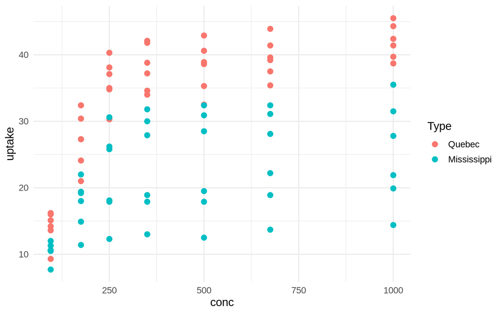

```r
p_points <- ggplot(CO2, aes(conc, uptake, colour = Type)) +
  geom_point(size = 2.5)

p_fits <- p_points +
  geom_smooth(method = "lm", se = FALSE)

p_final <- p_fits +
  facet_wrap(~ Treatment) +
  labs(
    title = "CO2 uptake versus ambient concentration",
    x = "Ambient CO2 concentration (mL/L)",
    y = "CO2 uptake rate (\u03bcmol/m\u00b2/s)",
    colour = "Origin"
  ) +
  theme_minimal(base_size = 12)

print(p_points)
```

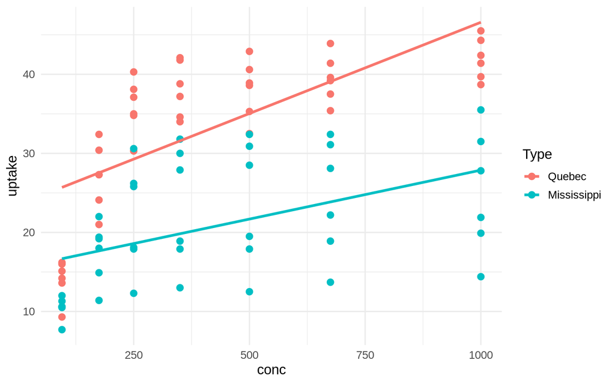

```r
print(p_fits)
```

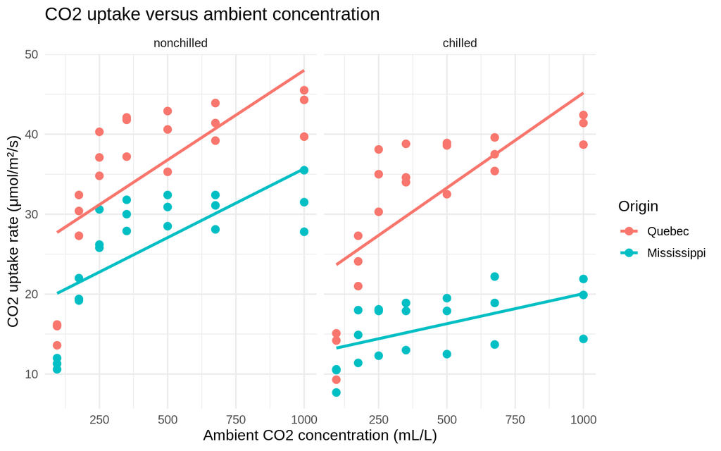

```r
print(p_final)
```

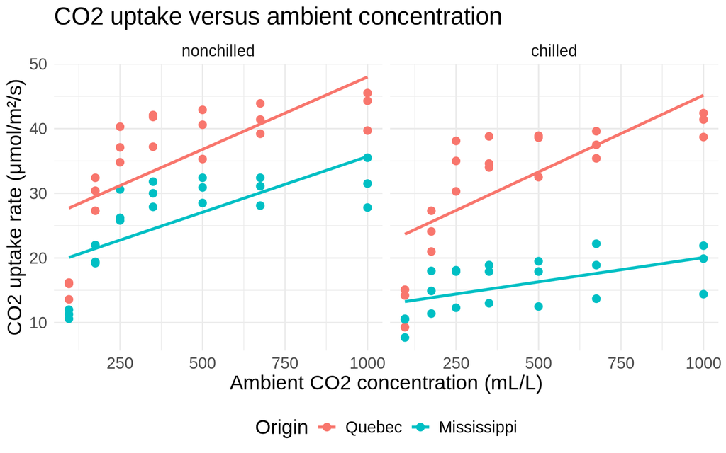

```r
dir.create("ggplot2_practice_output", showWarnings = FALSE)
ggsave(
  "ggplot2_practice_output/co2_summary.png",
  plot = p_final,
  width = 8,
  height = 5,
  units = "in",
  dpi = 300
)

saveRDS(p_final, "ggplot2_practice_output/co2_plot.rds")

restored <- readRDS("ggplot2_practice_output/co2_plot.rds")
restored_large <- restored +
  theme(
    legend.position = "bottom",
    text = element_text(size = 16)
  )
print(restored_large)
```

## 2.2 Exit ticket

1. What belongs inside `aes()`, and what belongs outside it?
2. Which object is your reusable starting point?
3. What is the difference between the PNG and the RDS file?

Sources: [ggplot2 reference](https://ggplot2.tidyverse.org/reference/), [ggplot2 book](https://ggplot2-book.org/), and [`ggsave()` documentation](https://ggplot2.tidyverse.org/reference/ggsave.html).